# hazi6_Natália

```r
df <- readRDS("CSM_data.RDS")
library(tidyverse)
```

```r
# install.packages("gplots")
library("gplots")
```

1. Jobb értékelést (Ratings) kapnak a sorozatok az onallo filmekkel szemben? A kérdés megválaszolásához az alábbi hipotéziseket állítottam fel:
   $$H_1: \mu_s > \mu_o , \space H_0: \mu_s \leq \mu_o$$
   A próba elvégzéséhez feltétel a csoportok normális eloszlása, illetve a szórások egyezősége. Ehhez manuálisan megnézzük a két csoport szórását, de F-próbát is végrehajtjuk.

```r
onallo_norm <- shapiro.test(df$Ratings [df$onallo==1])$p.value
sori_norm <- shapiro.test(df$Ratings [df$onallo==0])$p.value

onallo_szor <- sd(df$Ratings [df$onallo == 1])
sori_szor <- sd(df$Ratings [df$onallo == 0])
F_prob <- var.test(df$Ratings [df$onallo == 1],df$Ratings [df$onallo == 0])$p.value
names(onallo_szor) <- "Önállók szórása:"
names(sori_szor) <- "Sorozatok szórása:"
names(onallo_norm) <- "Önállók normalitástesztjének p-értéke:"
names(sori_norm) <- "sorozatok normalitástesztjének p-értéke:"
names(F_prob) <- "F-próba p-értéke:"
onallo_norm
```

```
## Önállók normalitástesztjének p-értéke:
##                              0.2465484
```

```r
sori_norm
```

```
## sorozatok normalitástesztjének p-értéke:
##                                0.2341801
```

```r
onallo_szor
```

```
## Önállók szórása:
##         1.010174
```

```r
sori_szor
```

```
## Sorozatok szórása:
##          0.9655747
```

```r
F_prob
```

```
## F-próba p-értéke:
##         0.7565583
```

Mivel az F-próba p-értéke nagyobb (utolsó adat), mint a választott szignifikanciaszint (1%), ezért azt a nullhipotézist, miszerint a két csoport szórása megegyezik elfogadjuk (nem tudjuk elvetni). A normalitásra is elvégeztem a megfelelő tesztet, amik hipotézisét ismét elfogadom, tehát normális eloszlást követ mindkét csoport ratingje. Tovább térhetünk a tesztre.

```r
t_prob <- t.test(x = df$Ratings [df$onallo == 1],y = df$Ratings [df$onallo == 0],alternative = "less",var.equal = T)
t <- t_prob[["statistic"]][["t"]]
r <- sqrt ( t^2 / (t^2 + t_prob[["parameter"]][["df"]]) )
t_prob
```

```
##
##  Two Sample t-test
##
## data:  df$Ratings[df$onallo == 1] and df$Ratings[df$onallo == 0]
## t = -0.33269, df = 185, p-value = 0.3699
## alternative hypothesis: true difference in means is less than 0
## 95 percent confidence interval:
##       -Inf 0.2314893
## sample estimates:
## mean of x mean of y
##  6.413103  6.471429
```

```r
t
```

```
## [1] -0.3326926
```

```r
r
```

```
## [1] 0.02445273
```

A nullhipotézist nem tudtuk elvetni, így 1%-os szignifikanciaszinten azt tudjuk mondani, hogy a sorozatok átlagos értékelései nem szignifikánsan nagyobbak, mint az önálló filmeké. Ezt az ellenőrzést grafikusan is elvégeztem, ahol látszik, hogy a két megoszlás átlaga körülbelül megegyezik. A próba hatásmérete kicsi, csupán 0.024 értéket mutat, de mivel nem volt szignifikáns a p-érték, ezért ez nem meglepő.

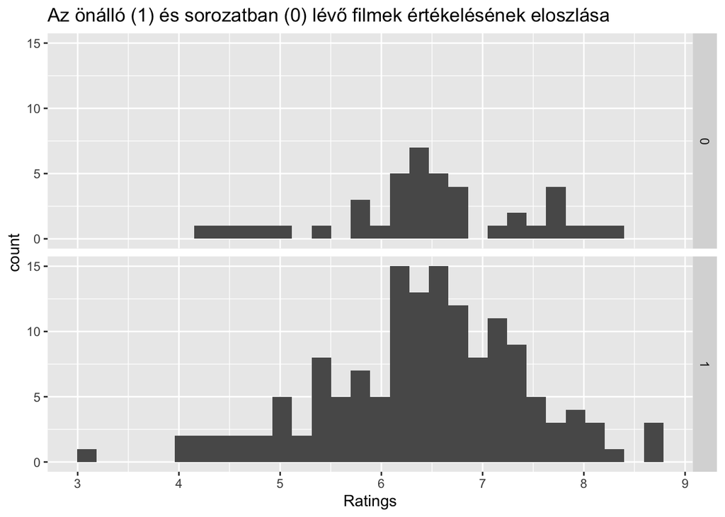

```r
ggplot2::ggplot(df)+
  geom_histogram(aes(x=Ratings))+
  facet_grid(rows=vars(onallo))+
  labs(title = "Az önálló (1) és sorozatban (0) lévő filmek értékelésének eloszlása")
```

2. Van-e szignifikans kapcsolat a film mufaja (Genre) es akozott, hogy a film onallo vagy sem (sorozat)? Szignifikans kapcsolat eseten jellemezd a kapcsolat erosseget is! A megfelelo statisztikai proba mellett, az dontes alatamasztasahoz szukseges abrat is keszitsd el! A feladat megoldásához először egy gyakorisági táblázatot kell készíteni:

```r
freq <- table(df$Genre, df$onallo)
freq
```

```
##
##       0  1
##   1  19 36
##   2   6  5
##   3   4 33
##   6   0  2
##   7   0  1
##   8   9 34
##   9   0 10
##   10  1  8
##   12  3  9
##   15  0  7
```

Ezután meg kell jegyeznünk, hogy a legkisebb értéknek legalább 5-nek kell lennie. Láthatjuk, hogy ez nem teljesül, így pontatlan lesz a khínégyzetünk. Ezzel a fenntartással kell tovább vizsgálódnunk. A gyakorisági táblát ábrán is megjelenítettem.

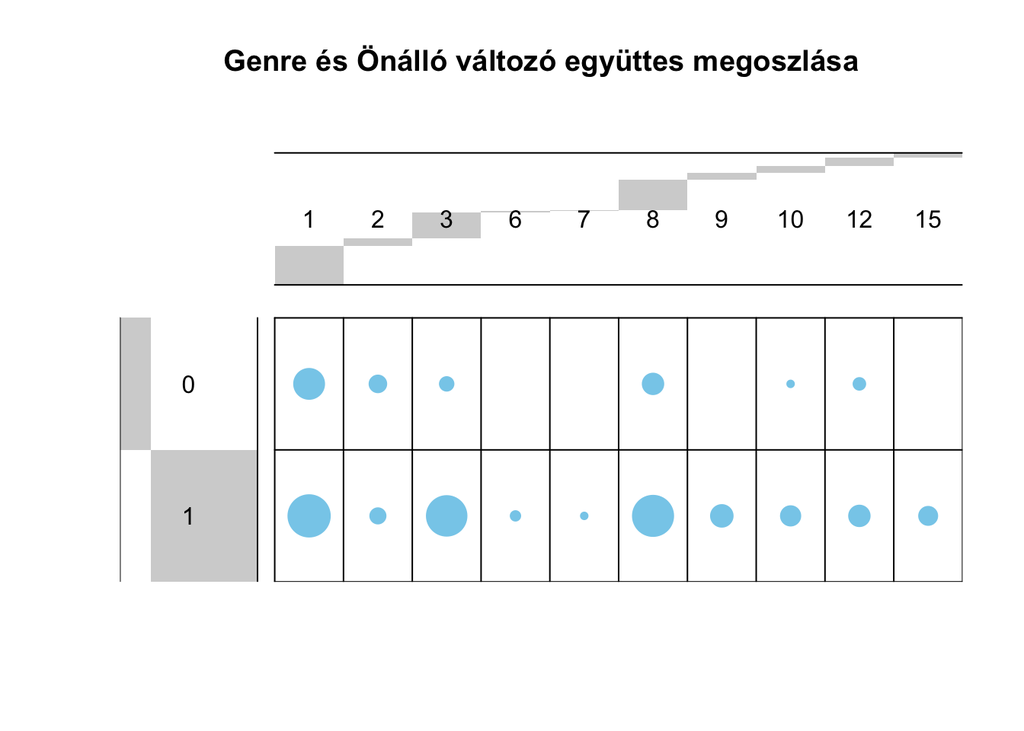

```r
balloonplot(freq, main ="Genre és Önálló változó együttes megoszlása", xlab ="", ylab="",
            label = FALSE, show.margins = FALSE)
```

Ezután meghatároztam a szakmai hipotéziseket:
$$H_0: f_{ij} = f_{ij}^* \space minden \space i,j-re, \space illetve\space H_1: a \space két\space változó\space nem \space független$$

```r
chisq <- chisq.test(freq)
chisq
```

```
##
##  Pearson's Chi-squared test
##
## data:  freq
## X-squared = 20.559, df = 9, p-value = 0.01476
```

*III) Van-e szignifikans kapcsolat akozott, hogy hany szazaleknak tetszett (rel_tetszett) a film es a Rating kozott? Szignifikans kapcsolat eseten jellemezd a kapcsolat erosseget is 99%-os megbízhatósággal! A megfelelo statisztikai proba mellett, a dontes alatamasztasahoz szukseges abrat is keszitsd el!*